# *Title: Dataset Investigation to assess trend of weapon purchasements in U.S*

1. Introduction and Problem Statement

2. Data Wrangling

1. Introduction and Problem Statement

1. Introduction and Problem Statement

###### *A. Introduction and Problem Statement* This project aims at investigating weapon purchasement in U.S.A. to statistically investigate and answer the following questions:*

###### *1)What census data is most associated with high gun per capita?*

###### *2)Which states have had the highest growth in gun registrations?*

###### *3)What is the overall trend of gun purchases?*

### *2. Data Wrangling*

#### Importing required libs and data from CSV files

```python
import pandas as pd
import numpy as np
import seaborn as sns
import matplotlib.pyplot as plt
import os
%matplotlib inline
```

```python
os.chdir('F:\\Python\\Project\\')# Setting work directory
print(os.getcwd())
```

```
F:\Python\Project
```

```python
df1=pd.read_csv('001_Raw gun_data.csv') #Importing 1rst data csv file, and reading it.
df2=pd.read_csv('u.s._census_data.csv') #Importing 2nd data csv file, and reading it.
```

#### prilimenary investigation

#### a) Gun Data

```python
df1.head(3)#showing first five rows as a data sample.
```

|  | month | state | permit | permit_recheck | handgun | long_gun | other | multiple | admin | prepawn_handgun | ... | returned_other | rentals_handgun | rentals_long_gun | private_sale_handgun | private_sale_long_gun | private_sale_other | return_to_seller_handgun | return_to_seller_long_gun | return_to_seller_other | totals |
| --- | --- | --- | --- | --- | --- | --- | --- | --- | --- | --- | --- | --- | --- | --- | --- | --- | --- | --- | --- | --- | --- |
| 0 | 2017-09 | Alabama | 16717.0 | 0.0 | 5734.0 | 6320.0 | 221.0 | 317 | 0.0 | 15.0 | ... | 0.0 | 0.0 | 0.0 | 9.0 | 16.0 | 3.0 | 0.0 | 0.0 | 3.0 | 32019 |
| 1 | 2017-09 | Alaska | 209.0 | 2.0 | 2320.0 | 2930.0 | 219.0 | 160 | 0.0 | 5.0 | ... | 0.0 | 0.0 | 0.0 | 17.0 | 24.0 | 1.0 | 0.0 | 0.0 | 0.0 | 6303 |
| 2 | 2017-09 | Arizona | 5069.0 | 382.0 | 11063.0 | 7946.0 | 920.0 | 631 | 0.0 | 13.0 | ... | 0.0 | 0.0 | 0.0 | 38.0 | 12.0 | 2.0 | 0.0 | 0.0 | 0.0 | 28394 |

3 rows × 27 columns

#### Note: There are some missing data as number of records in some columns less than the total number of records (12485), but totals are the most important item of data for calculating gun purchasement per capita for a state. this can be concluded from the .info() function below:

```python
df1.info() #explore
```

```
<class 'pandas.core.frame.DataFrame'>
RangeIndex: 12485 entries, 0 to 12484
Data columns (total 27 columns):
 #   Column                     Non-Null Count  Dtype
---  ------                     --------------  -----
 0   month                      12485 non-null  object
 1   state                      12485 non-null  object
 2   permit                     12461 non-null  float64
 3   permit_recheck             1100 non-null   float64
 4   handgun                    12465 non-null  float64
 5   long_gun                   12466 non-null  float64
 6   other                      5500 non-null   float64
 7   multiple                   12485 non-null  int64
 8   admin                      12462 non-null  float64
 9   prepawn_handgun            10542 non-null  float64
```

[output cut: 19 more lines]

#### Note: Preparing data for analysis, includes removing unneccessary columns from gun purchasement data. Data needed from dataframe no. 1 is the columns with lables :'month','state' and 'totals'. Any other columns will be removed and data frame will be assigned to another label ('df1_gun_totals') as follows:

```python
#exxclude uncessary columns
df1_gun_totals = df1[['month','state','totals']]
df1_gun_totals.head()
```

|  | month | state | totals |
| --- | --- | --- | --- |
| 0 | 2017-09 | Alabama | 32019 |
| 1 | 2017-09 | Alaska | 6303 |
| 2 | 2017-09 | Arizona | 28394 |
| 3 | 2017-09 | Arkansas | 17747 |
| 4 | 2017-09 | California | 123506 |

###### *Note: Consolidate all states that are in given data obtained from the first data frame, get the actual total no. of states in the data frame.*

###### *Afterwise, a check if all states are the same as given in data frame 2 is done as follows :*

```python
States=list(df1_gun_totals['state'][:])     #get all states existing in the first data set.
state_consolidated=[]
for state in States:                       #go through a loop to cummlitatvily collectct data in a list.
    if state not in state_consolidated:
        state_consolidated.append(state)
    else:
        continue

state_from_df1=state_consolidated
print(state_from_df1)                       #print the list contents to check them visually.
print(len(state_from_df1))


# check if states are the same in both files as strings and count
state_from_df2 = list(df2[df2.index < 0].drop(df2[['Fact','Fact Note']],axis = 1))
print(state_from_df2)
print(len(state_from_df2))
```

```
['Alabama', 'Alaska', 'Arizona', 'Arkansas', 'California', 'Colorado', 'Connecticut', 'Delaware', 'District of Columbia', 'Florida', 'Georgia', 'Guam', 'Hawaii', 'Idaho', 'Illinois', 'Indiana', 'Iowa', 'Kansas', 'Kentucky', 'Louisiana', 'Maine', 'Mariana Islands', 'Maryland', 'Massachusetts', 'Michi…
55
['Alabama', 'Alaska', 'Arizona', 'Arkansas', 'California', 'Colorado', 'Connecticut', 'Delaware', 'Florida', 'Georgia', 'Hawaii', 'Idaho', 'Illinois', 'Indiana', 'Iowa', 'Kansas', 'Kentucky', 'Louisiana', 'Maine', 'Maryland', 'Massachusetts', 'Michigan', 'Minnesota', 'Mississippi', 'Missouri', 'Mont…
50
```

###### *Note: Its obvious now that states mentioned in the second data frame (df2) are a little bit different from those in the first one*

###### *(df1_gun_totals). So, a list of the odd values should be created to make an analysis decison. This is done as below:*

```python
not_an_existing_states=[]
for state in state_from_df1:             # go through for loop to remove redundant items.
    if state not in state_from_df2:
        not_an_existing_states.append(state)
print(state_from_df1)
print(state_from_df2)
print(not_an_existing_states)
```

```
['Alabama', 'Alaska', 'Arizona', 'Arkansas', 'California', 'Colorado', 'Connecticut', 'Delaware', 'District of Columbia', 'Florida', 'Georgia', 'Guam', 'Hawaii', 'Idaho', 'Illinois', 'Indiana', 'Iowa', 'Kansas', 'Kentucky', 'Louisiana', 'Maine', 'Mariana Islands', 'Maryland', 'Massachusetts', 'Michi…
['Alabama', 'Alaska', 'Arizona', 'Arkansas', 'California', 'Colorado', 'Connecticut', 'Delaware', 'Florida', 'Georgia', 'Hawaii', 'Idaho', 'Illinois', 'Indiana', 'Iowa', 'Kansas', 'Kentucky', 'Louisiana', 'Maine', 'Maryland', 'Massachusetts', 'Michigan', 'Minnesota', 'Mississippi', 'Missouri', 'Mont…
['District of Columbia', 'Guam', 'Mariana Islands', 'Puerto Rico', 'Virgin Islands']
```

###### Note: So a small list of five states are existing in the data frame 1 while the contents of the same list are not existing in data frame 2. These 5 states are 'District of Columbia', 'Guam', 'Mariana Islands', 'Puerto Rico' and 'Virgin Islands'. Then these five states' data should be dropped from data frame 1. This is done in the following code lines:*

```python
for no_state in not_an_existing_states:
    df1_gun_totals = df1_gun_totals.drop(df1_gun_totals[df1_gun_totals['state']==no_state].index )
df1_gun_totals.reset_index()
```

|  | index | month | state | totals |
| --- | --- | --- | --- | --- |
| 0 | 0 | 2017-09 | Alabama | 32019 |
| 1 | 1 | 2017-09 | Alaska | 6303 |
| 2 | 2 | 2017-09 | Arizona | 28394 |
| 3 | 3 | 2017-09 | Arkansas | 17747 |
| 4 | 4 | 2017-09 | California | 123506 |
| ... | ... | ... | ... | ... |
| 11345 | 12480 | 1998-11 | Virginia | 24 |
| 11346 | 12481 | 1998-11 | Washington | 361 |
| 11347 | 12482 | 1998-11 | West Virginia | 408 |
| 11348 | 12483 | 1998-11 | Wisconsin | 241 |
| 11349 | 12484 | 1998-11 | Wyoming | 107 |

11350 rows × 4 columns

```python
df1_gun_totals['month'] = pd.to_datetime(df1_gun_totals['month']) #converting strings related to date into date type.
df1_gun_totals.info()
```

```
<class 'pandas.core.frame.DataFrame'>
Int64Index: 11350 entries, 0 to 12484
Data columns (total 3 columns):
 #   Column  Non-Null Count  Dtype
---  ------  --------------  -----
 0   month   11350 non-null  datetime64[ns]
 1   state   11350 non-null  object
 2   totals  11350 non-null  int64
dtypes: datetime64[ns](1), int64(1), object(1)
memory usage: 354.7+ KB
```

```python
df1_gun_totals.sort_values('month', ascending = False) #sorting on date basis
df1_gun_totals.head(1000)
```

|  | month | state | totals |
| --- | --- | --- | --- |
| 0 | 2017-09-01 | Alabama | 32019 |
| 1 | 2017-09-01 | Alaska | 6303 |
| 2 | 2017-09-01 | Arizona | 28394 |
| 3 | 2017-09-01 | Arkansas | 17747 |
| 4 | 2017-09-01 | California | 123506 |
| ... | ... | ... | ... |
| 1095 | 2016-02-01 | Virginia | 47955 |
| 1096 | 2016-02-01 | Washington | 56043 |
| 1097 | 2016-02-01 | West Virginia | 27216 |
| 1098 | 2016-02-01 | Wisconsin | 42855 |
| 1099 | 2016-02-01 | Wyoming | 5703 |

1000 rows × 3 columns

```python
gun_totals_16 = df1_gun_totals[df1_gun_totals['month']=='2016-07-01'] #separate2016 data items
gun_totals_10 = df1_gun_totals[df1_gun_totals['month']=='2010-04-01'] #separate2010 data items

gun_totals_10.info()
```

```
<class 'pandas.core.frame.DataFrame'>
Int64Index: 50 entries, 4895 to 4949
Data columns (total 3 columns):
 #   Column  Non-Null Count  Dtype
---  ------  --------------  -----
 0   month   50 non-null     datetime64[ns]
 1   state   50 non-null     object
 2   totals  50 non-null     int64
dtypes: datetime64[ns](1), int64(1), object(1)
memory usage: 1.6+ KB
```

```python
df2_reduced = df2.iloc[0:20 ,1:]
df2_reduced.drop(['Fact Note'], axis = 1, inplace = True)
```

```python
h_columns = list(df2_reduced.columns) #printing the header
h_columns[0]
print(h_columns)
```

```
['Alabama', 'Alaska', 'Arizona', 'Arkansas', 'California', 'Colorado', 'Connecticut', 'Delaware', 'Florida', 'Georgia', 'Hawaii', 'Idaho', 'Illinois', 'Indiana', 'Iowa', 'Kansas', 'Kentucky', 'Louisiana', 'Maine', 'Maryland', 'Massachusetts', 'Michigan', 'Minnesota', 'Mississippi', 'Missouri', 'Mont…
```

```python
df2_reduced.head(5)
```

|  | Alabama | Alaska | Arizona | Arkansas | California | Colorado | Connecticut | Delaware | Florida | Georgia | ... | South Dakota | Tennessee | Texas | Utah | Vermont | Virginia | Washington | West Virginia | Wisconsin | Wyoming |
| --- | --- | --- | --- | --- | --- | --- | --- | --- | --- | --- | --- | --- | --- | --- | --- | --- | --- | --- | --- | --- | --- |
| 0 | 4,863,300 | 741,894 | 6,931,071 | 2,988,248 | 39,250,017 | 5,540,545 | 3,576,452 | 952,065 | 20,612,439 | 10,310,371 | ... | 865454 | 6651194 | 27,862,596 | 3,051,217 | 624,594 | 8,411,808 | 7,288,000 | 1,831,102 | 5,778,708 | 585,501 |
| 1 | 4,780,131 | 710,249 | 6,392,301 | 2,916,025 | 37,254,522 | 5,029,324 | 3,574,114 | 897,936 | 18,804,592 | 9,688,680 | ... | 814195 | 6346298 | 25,146,100 | 2,763,888 | 625,741 | 8,001,041 | 6,724,545 | 1,853,011 | 5,687,289 | 563,767 |
| 2 | 1.70% | 4.50% | 8.40% | 2.50% | 5.40% | 10.20% | 0.10% | 6.00% | 9.60% | 6.40% | ... | 0.063 | 0.048 | 10.80% | 10.40% | -0.20% | 5.10% | 8.40% | -1.20% | 1.60% | 3.90% |
| 3 | 4,779,736 | 710,231 | 6,392,017 | 2,915,918 | 37,253,956 | 5,029,196 | 3,574,097 | 897,934 | 18,801,310 | 9,687,653 | ... | 814180 | 6346105 | 25,145,561 | 2,763,885 | 625,741 | 8,001,024 | 6,724,540 | 1,852,994 | 5,686,986 | 563,626 |
| 4 | 6.00% | 7.30% | 6.30% | 6.40% | 6.30% | 6.10% | 5.20% | 5.80% | 5.50% | 6.40% | ... | 0.071 | 0.061 | 7.20% | 8.30% | 4.90% | 6.10% | 6.20% | 5.50% | 5.80% | 6.50% |

5 rows × 50 columns

```python
df3=df2_reduced
for state in h_columns:   #going into a loop to clear all unwanted strings.
    df3[:][state] = df2[:][state].str.replace(',', '')
df3.head()
```

|  | Alabama | Alaska | Arizona | Arkansas | California | Colorado | Connecticut | Delaware | Florida | Georgia | ... | South Dakota | Tennessee | Texas | Utah | Vermont | Virginia | Washington | West Virginia | Wisconsin | Wyoming |
| --- | --- | --- | --- | --- | --- | --- | --- | --- | --- | --- | --- | --- | --- | --- | --- | --- | --- | --- | --- | --- | --- |
| 0 | 4863300 | 741894 | 6931071 | 2988248 | 39250017 | 5540545 | 3576452 | 952065 | 20612439 | 10310371 | ... | 865454 | 6651194 | 27862596 | 3051217 | 624594 | 8411808 | 7288000 | 1831102 | 5778708 | 585501 |
| 1 | 4780131 | 710249 | 6392301 | 2916025 | 37254522 | 5029324 | 3574114 | 897936 | 18804592 | 9688680 | ... | 814195 | 6346298 | 25146100 | 2763888 | 625741 | 8001041 | 6724545 | 1853011 | 5687289 | 563767 |
| 2 | 1.70% | 4.50% | 8.40% | 2.50% | 5.40% | 10.20% | 0.10% | 6.00% | 9.60% | 6.40% | ... | 0.063 | 0.048 | 10.80% | 10.40% | -0.20% | 5.10% | 8.40% | -1.20% | 1.60% | 3.90% |
| 3 | 4779736 | 710231 | 6392017 | 2915918 | 37253956 | 5029196 | 3574097 | 897934 | 18801310 | 9687653 | ... | 814180 | 6346105 | 25145561 | 2763885 | 625741 | 8001024 | 6724540 | 1852994 | 5686986 | 563626 |
| 4 | 6.00% | 7.30% | 6.30% | 6.40% | 6.30% | 6.10% | 5.20% | 5.80% | 5.50% | 6.40% | ... | 0.071 | 0.061 | 7.20% | 8.30% | 4.90% | 6.10% | 6.20% | 5.50% | 5.80% | 6.50% |

5 rows × 50 columns

```python
# removing "%" sign from all strings
for state in h_columns:
    df3[:][state] = (df3[:][state].str.strip('%'))
df3.head()
```

|  | Alabama | Alaska | Arizona | Arkansas | California | Colorado | Connecticut | Delaware | Florida | Georgia | ... | South Dakota | Tennessee | Texas | Utah | Vermont | Virginia | Washington | West Virginia | Wisconsin | Wyoming |
| --- | --- | --- | --- | --- | --- | --- | --- | --- | --- | --- | --- | --- | --- | --- | --- | --- | --- | --- | --- | --- | --- |
| 0 | 4863300 | 741894 | 6931071 | 2988248 | 39250017 | 5540545 | 3576452 | 952065 | 20612439 | 10310371 | ... | 865454 | 6651194 | 27862596 | 3051217 | 624594 | 8411808 | 7288000 | 1831102 | 5778708 | 585501 |
| 1 | 4780131 | 710249 | 6392301 | 2916025 | 37254522 | 5029324 | 3574114 | 897936 | 18804592 | 9688680 | ... | 814195 | 6346298 | 25146100 | 2763888 | 625741 | 8001041 | 6724545 | 1853011 | 5687289 | 563767 |
| 2 | 1.70 | 4.50 | 8.40 | 2.50 | 5.40 | 10.20 | 0.10 | 6.00 | 9.60 | 6.40 | ... | 0.063 | 0.048 | 10.80 | 10.40 | -0.20 | 5.10 | 8.40 | -1.20 | 1.60 | 3.90 |
| 3 | 4779736 | 710231 | 6392017 | 2915918 | 37253956 | 5029196 | 3574097 | 897934 | 18801310 | 9687653 | ... | 814180 | 6346105 | 25145561 | 2763885 | 625741 | 8001024 | 6724540 | 1852994 | 5686986 | 563626 |
| 4 | 6.00 | 7.30 | 6.30 | 6.40 | 6.30 | 6.10 | 5.20 | 5.80 | 5.50 | 6.40 | ... | 0.071 | 0.061 | 7.20 | 8.30 | 4.90 | 6.10 | 6.20 | 5.50 | 5.80 | 6.50 |

5 rows × 50 columns

```python
# still cleaning data
for state in h_columns:
    df3[:][state] = df3[:][state].str.replace('Z', '0.0')
df3.head()
```

|  | Alabama | Alaska | Arizona | Arkansas | California | Colorado | Connecticut | Delaware | Florida | Georgia | ... | South Dakota | Tennessee | Texas | Utah | Vermont | Virginia | Washington | West Virginia | Wisconsin | Wyoming |
| --- | --- | --- | --- | --- | --- | --- | --- | --- | --- | --- | --- | --- | --- | --- | --- | --- | --- | --- | --- | --- | --- |
| 0 | 4863300 | 741894 | 6931071 | 2988248 | 39250017 | 5540545 | 3576452 | 952065 | 20612439 | 10310371 | ... | 865454 | 6651194 | 27862596 | 3051217 | 624594 | 8411808 | 7288000 | 1831102 | 5778708 | 585501 |
| 1 | 4780131 | 710249 | 6392301 | 2916025 | 37254522 | 5029324 | 3574114 | 897936 | 18804592 | 9688680 | ... | 814195 | 6346298 | 25146100 | 2763888 | 625741 | 8001041 | 6724545 | 1853011 | 5687289 | 563767 |
| 2 | 1.70 | 4.50 | 8.40 | 2.50 | 5.40 | 10.20 | 0.10 | 6.00 | 9.60 | 6.40 | ... | 0.063 | 0.048 | 10.80 | 10.40 | -0.20 | 5.10 | 8.40 | -1.20 | 1.60 | 3.90 |
| 3 | 4779736 | 710231 | 6392017 | 2915918 | 37253956 | 5029196 | 3574097 | 897934 | 18801310 | 9687653 | ... | 814180 | 6346105 | 25145561 | 2763885 | 625741 | 8001024 | 6724540 | 1852994 | 5686986 | 563626 |
| 4 | 6.00 | 7.30 | 6.30 | 6.40 | 6.30 | 6.10 | 5.20 | 5.80 | 5.50 | 6.40 | ... | 0.071 | 0.061 | 7.20 | 8.30 | 4.90 | 6.10 | 6.20 | 5.50 | 5.80 | 6.50 |

5 rows × 50 columns

```python
# convert all numeric data into floats
for state in h_columns:
    df3[:][state] = df3[:][state].astype('float')
df3.head()
```

|  | Alabama | Alaska | Arizona | Arkansas | California | Colorado | Connecticut | Delaware | Florida | Georgia | ... | South Dakota | Tennessee | Texas | Utah | Vermont | Virginia | Washington | West Virginia | Wisconsin | Wyoming |
| --- | --- | --- | --- | --- | --- | --- | --- | --- | --- | --- | --- | --- | --- | --- | --- | --- | --- | --- | --- | --- | --- |
| 0 | 4863300 | 741894 | 6931071 | 2988248 | 39250017 | 5540545 | 3576452 | 952065 | 20612439 | 10310371 | ... | 865454 | 6651194 | 27862596 | 3051217 | 624594 | 8411808 | 7288000 | 1831102 | 5778708 | 585501 |
| 1 | 4780131 | 710249 | 6392301 | 2916025 | 37254522 | 5029324 | 3574114 | 897936 | 18804592 | 9688680 | ... | 814195 | 6346298 | 25146100 | 2763888 | 625741 | 8001041 | 6724545 | 1853011 | 5687289 | 563767 |
| 2 | 1.70 | 4.50 | 8.40 | 2.50 | 5.40 | 10.20 | 0.10 | 6.00 | 9.60 | 6.40 | ... | 0.063 | 0.048 | 10.80 | 10.40 | -0.20 | 5.10 | 8.40 | -1.20 | 1.60 | 3.90 |
| 3 | 4779736 | 710231 | 6392017 | 2915918 | 37253956 | 5029196 | 3574097 | 897934 | 18801310 | 9687653 | ... | 814180 | 6346105 | 25145561 | 2763885 | 625741 | 8001024 | 6724540 | 1852994 | 5686986 | 563626 |
| 4 | 6.00 | 7.30 | 6.30 | 6.40 | 6.30 | 6.10 | 5.20 | 5.80 | 5.50 | 6.40 | ... | 0.071 | 0.061 | 7.20 | 8.30 | 4.90 | 6.10 | 6.20 | 5.50 | 5.80 | 6.50 |

5 rows × 50 columns

```python
# convert all percentages into ratios
for i in range(0,20):
    for state in h_columns:
        df3.loc[[i],[state]]=(df3.loc[[i],[state]]).astype('float')/100
df3.head()
```

|  | Alabama | Alaska | Arizona | Arkansas | California | Colorado | Connecticut | Delaware | Florida | Georgia | ... | South Dakota | Tennessee | Texas | Utah | Vermont | Virginia | Washington | West Virginia | Wisconsin | Wyoming |
| --- | --- | --- | --- | --- | --- | --- | --- | --- | --- | --- | --- | --- | --- | --- | --- | --- | --- | --- | --- | --- | --- |
| 0 | 48633 | 7418.94 | 69310.7 | 29882.5 | 392500 | 55405.4 | 35764.5 | 9520.65 | 206124 | 103104 | ... | 8654.54 | 66511.9 | 278626 | 30512.2 | 6245.94 | 84118.1 | 72880 | 18311 | 57787.1 | 5855.01 |
| 1 | 47801.3 | 7102.49 | 63923 | 29160.2 | 372545 | 50293.2 | 35741.1 | 8979.36 | 188046 | 96886.8 | ... | 8141.95 | 63463 | 251461 | 27638.9 | 6257.41 | 80010.4 | 67245.4 | 18530.1 | 56872.9 | 5637.67 |
| 2 | 0.017 | 0.045 | 0.084 | 0.025 | 0.054 | 0.102 | 0.001 | 0.06 | 0.096 | 0.064 | ... | 0.00063 | 0.00048 | 0.108 | 0.104 | -0.002 | 0.051 | 0.084 | -0.012 | 0.016 | 0.039 |
| 3 | 47797.4 | 7102.31 | 63920.2 | 29159.2 | 372540 | 50292 | 35741 | 8979.34 | 188013 | 96876.5 | ... | 8141.8 | 63461.1 | 251456 | 27638.8 | 6257.41 | 80010.2 | 67245.4 | 18529.9 | 56869.9 | 5636.26 |
| 4 | 0.06 | 0.073 | 0.063 | 0.064 | 0.063 | 0.061 | 0.052 | 0.058 | 0.055 | 0.064 | ... | 0.00071 | 0.00061 | 0.072 | 0.083 | 0.049 | 0.061 | 0.062 | 0.055 | 0.058 | 0.065 |

5 rows × 50 columns

```python
# prepare 'Fact' column to concatenate it
fact_col=df2[:20]['Fact']
fact_col.head(25)
ttt=df2.loc[1]['Fact']
ttt
```

```
'Population estimates base, April 1, 2010,  (V2016)'
```

```python
n_frame=[fact_col,df3]
df3=pd.concat(n_frame,axis = 1)
df3.head()
```

|  | Fact | Alabama | Alaska | Arizona | Arkansas | California | Colorado | Connecticut | Delaware | Florida | ... | South Dakota | Tennessee | Texas | Utah | Vermont | Virginia | Washington | West Virginia | Wisconsin | Wyoming |
| --- | --- | --- | --- | --- | --- | --- | --- | --- | --- | --- | --- | --- | --- | --- | --- | --- | --- | --- | --- | --- | --- |
| 0 | Population estimates, July 1, 2016, (V2016) | 48633 | 7418.94 | 69310.7 | 29882.5 | 392500 | 55405.4 | 35764.5 | 9520.65 | 206124 | ... | 8654.54 | 66511.9 | 278626 | 30512.2 | 6245.94 | 84118.1 | 72880 | 18311 | 57787.1 | 5855.01 |
| 1 | Population estimates base, April 1, 2010, (V2... | 47801.3 | 7102.49 | 63923 | 29160.2 | 372545 | 50293.2 | 35741.1 | 8979.36 | 188046 | ... | 8141.95 | 63463 | 251461 | 27638.9 | 6257.41 | 80010.4 | 67245.4 | 18530.1 | 56872.9 | 5637.67 |
| 2 | Population, percent change - April 1, 2010 (es... | 0.017 | 0.045 | 0.084 | 0.025 | 0.054 | 0.102 | 0.001 | 0.06 | 0.096 | ... | 0.00063 | 0.00048 | 0.108 | 0.104 | -0.002 | 0.051 | 0.084 | -0.012 | 0.016 | 0.039 |
| 3 | Population, Census, April 1, 2010 | 47797.4 | 7102.31 | 63920.2 | 29159.2 | 372540 | 50292 | 35741 | 8979.34 | 188013 | ... | 8141.8 | 63461.1 | 251456 | 27638.8 | 6257.41 | 80010.2 | 67245.4 | 18529.9 | 56869.9 | 5636.26 |
| 4 | Persons under 5 years, percent, July 1, 2016, ... | 0.06 | 0.073 | 0.063 | 0.064 | 0.063 | 0.061 | 0.052 | 0.058 | 0.055 | ... | 0.00071 | 0.00061 | 0.072 | 0.083 | 0.049 | 0.061 | 0.062 | 0.055 | 0.058 | 0.065 |

5 rows × 51 columns

###### *Note: Now, all unneccery records should be dropped for preparing data from census_10 and census_16 for comparisons. To accomplish comparisons on multiple variables all census data should be converted from percentages into population:*

```python
# removing uncessary rows
census_16=df3
print(census_16['Fact'][3])
rmoving_criteria=['April 1, 2010', 'Persons under 5 years', 'Persons 65 years and ove']
for stri in rmoving_criteria:
    list_of_removal_indx = census_16.index[census_16['Fact'].str.contains(stri)].tolist()
    if 3 in list_of_removal_indx:
        list_of_removal_indx.remove(3)
    print(list_of_removal_indx )#exlude 2010 censusfrom removal cre=iteria
    census_16.drop(index=list_of_removal_indx,inplace = True)
    census_16.reset_index(drop=True,inplace=True)
census16=census_16
```

```
Population, Census, April 1, 2010
[1, 2, 5, 7, 9, 11]
[2]
[]
```

```python
#  convert all ratios to values
for col_indx in range(1,len(census_16.columns)):
    for row_indx in range(2,11):
        census_16.iloc[0,col_indx]=int(census_16.iloc[0,col_indx])
        census_16.iloc[1,col_indx]=int(census_16.iloc[1,col_indx])
        census_16.iloc[row_indx,col_indx] = int(census_16.iloc[0,col_indx]*census_16.iloc[row_indx,col_indx])
cen_16_10=census_16
```

```python
totals=gun_totals_10.merge(gun_totals_16, on='state', how='left')    #merging dataframes
totals.head()
```

|  | month_x | state | totals_x | month_y | totals_y |
| --- | --- | --- | --- | --- | --- |
| 0 | 2010-04-01 | Alabama | 20791 | 2016-07-01 | 48927 |
| 1 | 2010-04-01 | Alaska | 6411 | 2016-07-01 | 6793 |
| 2 | 2010-04-01 | Arizona | 16578 | 2016-07-01 | 34496 |
| 3 | 2010-04-01 | Arkansas | 14563 | 2016-07-01 | 19378 |
| 4 | 2010-04-01 | California | 80750 | 2016-07-01 | 190218 |

```python
lable16=cen_16_10['Fact'][0]
print(lable16)
lable10=cen_16_10['Fact'][1]
print(lable10)
```

```
Population estimates, July 1, 2016,  (V2016)
Population, Census, April 1, 2010
```

```python
df_16 = cen_16_10[cen_16_10['Fact']==lable16]
df17=df_16.T
df17L=df17[0].tolist()
df17L.remove(df17L[0])
print(df17L)
```

```
[48633, 7418, 69310, 29882, 392500, 55405, 35764, 9520, 206124, 103103, 14285, 16831, 128015, 66330, 31346, 29072, 44369, 46816, 13314, 60164, 68117, 99283, 55199, 29887, 60930, 10425, 19071, 29400, 13347, 89444, 20810, 197452, 101467, 7579, 116143, 39235, 40934, 127842, 10564, 49611, 8654, 66511, 2…
```

```python
totals.insert(4,'populationy',df17L)
totals.head()
```

|  | month_x | state | totals_x | month_y | populationy | totals_y |
| --- | --- | --- | --- | --- | --- | --- |
| 0 | 2010-04-01 | Alabama | 20791 | 2016-07-01 | 48633 | 48927 |
| 1 | 2010-04-01 | Alaska | 6411 | 2016-07-01 | 7418 | 6793 |
| 2 | 2010-04-01 | Arizona | 16578 | 2016-07-01 | 69310 | 34496 |
| 3 | 2010-04-01 | Arkansas | 14563 | 2016-07-01 | 29882 | 19378 |
| 4 | 2010-04-01 | California | 80750 | 2016-07-01 | 392500 | 190218 |

```python
df_10 = cen_16_10[cen_16_10['Fact']==lable10]
df10=df_10.T            #transposing the vectors paving the way for concatination
```

```python
df10.head()
```

|  | 1 |
| --- | --- |
| Fact | Population, Census, April 1, 2010 |
| Alabama | 47797 |
| Alaska | 7102 |
| Arizona | 63920 |
| Arkansas | 29159 |

```python
df10L=df10[1].tolist()
df10L.remove(df10L[0])
print(df10L)
```

```
[47797, 7102, 63920, 29159, 372539, 50291, 35740, 8979, 188013, 96876, 13603, 15675, 128306, 64838, 30463, 28531, 43393, 45333, 13283, 57735, 65476, 98836, 53039, 29672, 59889, 9894, 18263, 27005, 13164, 87918, 20591, 193781, 95354, 6725, 115365, 37513, 38310, 127023, 10525, 46253, 8141, 63461, 2514…
```

```python
totals.insert(1,'populationx',df10L)  #inserting the new columns in positions.
totals.head()
```

|  | month_x | populationx | state | totals_x | month_y | populationy | totals_y |
| --- | --- | --- | --- | --- | --- | --- | --- |
| 0 | 2010-04-01 | 47797 | Alabama | 20791 | 2016-07-01 | 48633 | 48927 |
| 1 | 2010-04-01 | 7102 | Alaska | 6411 | 2016-07-01 | 7418 | 6793 |
| 2 | 2010-04-01 | 63920 | Arizona | 16578 | 2016-07-01 | 69310 | 34496 |
| 3 | 2010-04-01 | 29159 | Arkansas | 14563 | 2016-07-01 | 29882 | 19378 |
| 4 | 2010-04-01 | 372539 | California | 80750 | 2016-07-01 | 392500 | 190218 |

```python
totals=totals.reindex(columns=['state','month_x','populationx','totals_x','month_y', 'populationy','totals_y'])
totals.head()
```

|  | state | month_x | populationx | totals_x | month_y | populationy | totals_y |
| --- | --- | --- | --- | --- | --- | --- | --- |
| 0 | Alabama | 2010-04-01 | 47797 | 20791 | 2016-07-01 | 48633 | 48927 |
| 1 | Alaska | 2010-04-01 | 7102 | 6411 | 2016-07-01 | 7418 | 6793 |
| 2 | Arizona | 2010-04-01 | 63920 | 16578 | 2016-07-01 | 69310 | 34496 |
| 3 | Arkansas | 2010-04-01 | 29159 | 14563 | 2016-07-01 | 29882 | 19378 |
| 4 | California | 2010-04-01 | 372539 | 80750 | 2016-07-01 | 392500 | 190218 |

```python
handgun=list(df1.handgun)
long_gun=list(df1.long_gun)
other=list(df1.other)
multiple=list(df1.multiple)
```

```python
totals.describe()

# from table below, it is obvious that within the six years period the average totals are doubled from 2010 to 2016
```

|  | populationx | totals_x | populationy | totals_y |
| --- | --- | --- | --- | --- |
| count | 50.000000 | 50.0000 | 50.000000 | 50.000000 |
| mean | 61628.260000 | 24517.7400 | 64488.780000 | 43710.400000 |
| std | 68482.396305 | 34280.1673 | 72717.685164 | 61544.999748 |
| min | 5636.000000 | 963.0000 | 5855.000000 | 1565.000000 |
| 25% | 18329.500000 | 7197.5000 | 18501.000000 | 11823.000000 |
| 50% | 44363.000000 | 15242.5000 | 45592.500000 | 25379.500000 |
| 75% | 66802.750000 | 26335.5000 | 71987.500000 | 46008.500000 |
| max | 372539.000000 | 211261.0000 | 392500.000000 | 363085.000000 |

```python
totals.info()
```

```
<class 'pandas.core.frame.DataFrame'>
Int64Index: 50 entries, 0 to 49
Data columns (total 7 columns):
 #   Column       Non-Null Count  Dtype
---  ------       --------------  -----
 0   state        50 non-null     object
 1   month_x      50 non-null     datetime64[ns]
 2   populationx  50 non-null     int64
 3   totals_x     50 non-null     int64
 4   month_y      50 non-null     datetime64[ns]
 5   populationy  50 non-null     int64
 6   totals_y     50 non-null     int64
dtypes: datetime64[ns](2), int64(4), object(1)
memory usage: 3.1+ KB
```

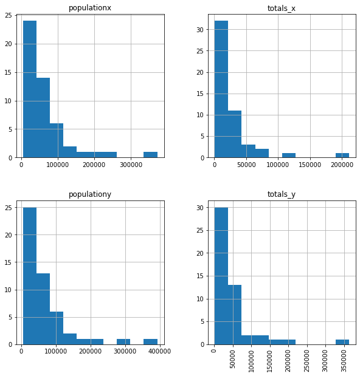

```python
totals.hist(['populationx','totals_x','populationy','totals_y'],figsize=(10,10))
plt.xticks(rotation=90);
```

```python
# c =totals.columns.to_list()
# print(c)
# z=totals.query('populationx>50')
# z
```

from hstograms above show that each variable is skew to trhe right. then also most variables have outliers that should be investigated. Next lines will investigate each variable outliers individually.

```
populationx
column :populationx  -54380.375  to   139512.625
df1_outliers_smaller_indx: [],  df1_outliers_greater_indx:  [4, 8, 31, 42]
totals_x
column :totals_x  -20082.25  to   51953.75
df1_outliers_smaller_indx: [],  df1_outliers_greater_indx:  [12, 16, 43]
```

```
populationy
column :populationy  -60735.75  to   142714.25
df1_outliers_smaller_indx: [],  df1_outliers_greater_indx:  []
totals_y
column :totals_y  -39917.75  to   93120.25
df1_outliers_smaller_indx: [],  df1_outliers_greater_indx:  []
```

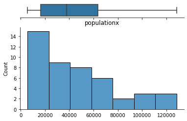

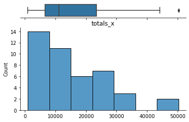

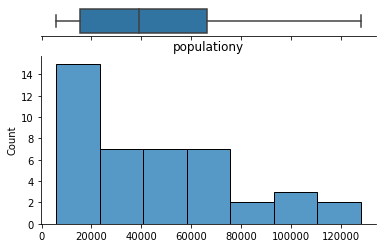

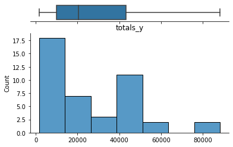

```python
# determine outliers arnge

def rem_outliers(df_in):
    df=df_in
    for col_lable in df.columns.tolist():
        if (col_lable=='state') or (col_lable=='month_x') or  (col_lable=='month_y'):
            continue
        print(col_lable)
        q1=df[col_lable].quantile(0.25)
        q3=df[col_lable].quantile(0.75)
        IQR=q3-q1
        outlaiers_lower_R=q1-1.5*IQR
        outlaiers_Upper_R=q3+1.5*IQR
        print('column :{}  {}  to   {}'.format(col_lable,outlaiers_lower_R, outlaiers_Upper_R))
        df1=df
        df1_outliers_smaller_indx=df1[df1[col_lable] < outlaiers_lower_R].index.tolist()
        df1_outliers_greater_indx=df1[df1[col_lable] > outlaiers_Upper_R].index.tolist()
        print('df1_outliers_smaller_indx: {},  df1_outliers_greater_indx:  {}  '.format(df1_outliers_smaller_indx,df1_outliers_greater_indx))
        df1.drop(index=df1[df1[col_lable] < outlaiers_lower_R].index.tolist(),axis=1,inplace=True)
        df1.drop(index=df1[df1[col_lable] > outlaiers_Upper_R].index.tolist(),axis=1,inplace=True)
        lis=df1[col_lable].values.tolist()
#       print(lis)
        f, (ax_box, ax_hist) = plt.subplots(2, sharex=True, gridspec_kw={"height_ratios": (.15, .85)})
        sns.boxplot(lis, ax=ax_box)
        sns.histplot(lis, ax=ax_hist).set_title(col_lable)
        ax_box.set(yticks=[])
        sns.despine(ax=ax_hist)
        sns.despine(ax=ax_box, left=True)

rem_outliers(totals)
```

```
No handles with labels found to put in legend.
```

```
totals_x
column :totals_x  -17756.875  to   47024.125
Series([], Name: state, dtype: object) Series([], Name: state, dtype: object)
df1_outliers_smaller_indx: [],  df1_outliers_greater_indx:  []
outilers for totals_x are located in the states :
```

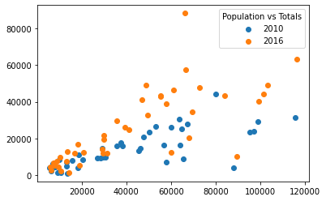

```
No handles with labels found to put in legend.
```

```
totals_y
column :totals_y  -39078.75  to   91585.25
Series([], Name: state, dtype: object) Series([], Name: state, dtype: object)
df1_outliers_smaller_indx: [],  df1_outliers_greater_indx:  []
outilers for totals_y are located in the states :
```

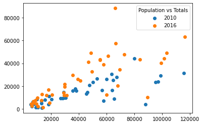

```python
# 1)determine outliers arnge

def draw_sc(df_in):
    df=df_in
    for col_lable in ['totals_x', 'totals_y']:
        print(col_lable)
        q1=df[col_lable].quantile(0.25)
        q3=df[col_lable].quantile(0.75)
        IQR=q3-q1
        outlaiers_lower_R=q1-1.5*IQR
        outlaiers_Upper_R=q3+1.5*IQR
        print('column :{}  {}  to   {}'.format(col_lable,outlaiers_lower_R, outlaiers_Upper_R))
        df1=df
        df1_outliers_smaller_indx=df1[df1[col_lable] < outlaiers_lower_R].index.tolist()
        df1_outliers_greater_indx=df1[df1[col_lable] > outlaiers_Upper_R].index.tolist()

        states_df1_outliers_smaller_indx=df1.iloc[df1_outliers_smaller_indx,0]
        states_df1_outliers_greater_indx=df1.iloc[df1_outliers_greater_indx,0]
        print(states_df1_outliers_smaller_indx,states_df1_outliers_greater_indx)
        print('df1_outliers_smaller_indx: {},  df1_outliers_greater_indx:  {}  '.format(df1_outliers_smaller_indx,df1_outliers_greater_indx))
        print('outilers for {} are located in the states : '.format(col_lable))
        df1.drop(index=df1[df1[col_lable] < outlaiers_lower_R].index.tolist(),axis=1,inplace=True)
        df1.drop(index=df1[df1[col_lable] > outlaiers_Upper_R].index.tolist(),axis=1,inplace=True)


        # then, 2)draw scatter plots
        fig, ax = plt.subplots()


        x1 = df1['populationx'].tolist()
        y1 = df1['totals_x'].tolist()
        x2 = df1['populationy'].tolist()
        y2 = df1['totals_y'].tolist()

        ax.scatter(x1, y1)
        ax.scatter(x2, y2)
        #  produce a legend with the unique colors from the scatter
        legend1 = ax.legend()
        # produce a legend with a cross section of sizes from the scatter
        handles = ['2010','2016']
        legend2 = ax.legend(handles, loc="upper right", title="Population vs Totals")

        plt.show()



draw_sc(totals)
```

###### From table of corr() funccytion below it seems that there is A moderate uphill (positive) relationship between totals of guns in 2010 (totals_x) and population in the smae year (populationx) and between totals of guns in 2016 (totals_y) and population in the smae year (populationy) . This is good enoguh to be considered for strong relation ship.

```python
totals.corr()
```

|  | populationx | totals_x | populationy | totals_y |
| --- | --- | --- | --- | --- |
| populationx | 1.000000 | 0.760762 | 0.998907 | 0.748726 |
| totals_x | 0.760762 | 1.000000 | 0.764721 | 0.863267 |
| populationy | 0.998907 | 0.764721 | 1.000000 | 0.749941 |
| totals_y | 0.748726 | 0.863267 | 0.749941 | 1.000000 |

###### Heat map represntation of variuos correllations below, emphasizes the meaning of the numeric data in the previous table. Here, a correlation factors that exceeds 0.74 for both correlations mentioned above.

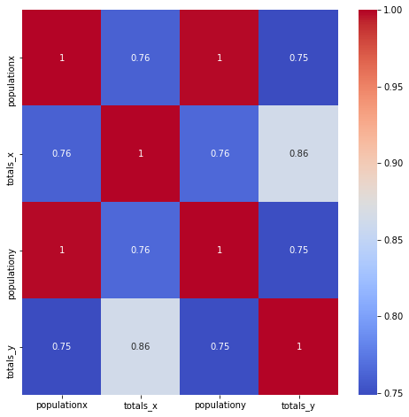

```python
plt.figure(figsize=(8,8))
sns.heatmap(totals.corr(),annot=True,cmap='coolwarm');
```

###### In the two figures below, both selected well correlated variables are plotted as scatter plot.

###### The figures below shows a proportional relation that may be well analysed by regression analysis.

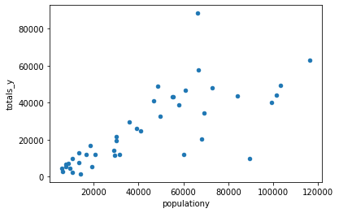

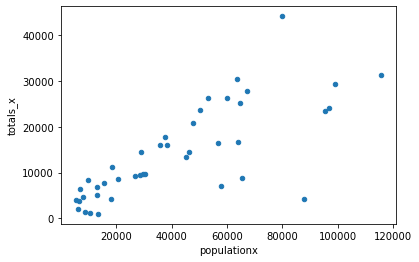

```python
totals.plot(kind='scatter',x='populationy',y='totals_y');
totals.plot(kind='scatter',x='populationx',y='totals_x');
```

```python
def gun_per_cap(data_frame):  #defining afunction that recieves a data frame and returns gun per capita ratio.
    pop10=[]
    pop16=[]
    tot10=[]
    tot16=[]
    for i in range(0,len(data_frame.iloc[:,0])):
        pop10.append(totals.iloc[i,2].sum())
        pop16.append(totals.iloc[i,5].sum())
        tot10.append(totals.iloc[i,3].sum())
        tot16.append(totals.iloc[i,6].sum())
    spop10=sum(pop10)
    spop16=sum(pop16)
    stot10=sum(tot10)
    stot16=sum(tot16)
    gpc10=stot10/spop10
    gpc16=stot16/spop16
    gpc=[gpc10,gpc16]
    return gpc #print('GunPerCapita ratio for both yers, 2010 and 2016 are: {} and {}.'.format(gpc[0],gpc[1]))

gpc=gun_per_cap(totals)
print(gpc)
```

```
[0.3387679968443889, 0.5928075865860363]
```

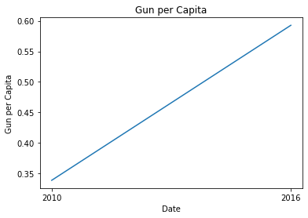

```python
date=['2010','2016']
plt.title('Gun per Capita')
plt.xlabel('Date')
plt.ylabel('Gun per Capita')
plt.plot(date, gpc)
plt.show()
# from figure shown below it is obvious that the relation is linear at as assumtion of a linear interpoliation.
```

```python
dftemp1=df1.iloc[:,[0, 4,5,6,7]]
dftemp2=dftemp1[dftemp1['month'].str.contains('2010-04')]
dftemp3=dftemp1[dftemp1['month'].str.contains('2016-07')]
```

```python
df4=pd.concat([dftemp2,dftemp3],axis=0)
```

```python
df4.head(4)
```

|  | month | handgun | long_gun | other | multiple |
| --- | --- | --- | --- | --- | --- |
| 4895 | 2010-04 | 8727.0 | 8095.0 | 131.0 | 394 |
| 4896 | 2010-04 | 2650.0 | 3136.0 | 64.0 | 135 |
| 4897 | 2010-04 | 7787.0 | 5097.0 | 198.0 | 309 |
| 4898 | 2010-04 | 3865.0 | 3833.0 | 45.0 | 197 |

```python
top_10_in_2010=totals.sort_values(['totals_x'],ascending=False).head(10)
top_10_in_2016=totals.sort_values(['totals_y'],ascending=False).head(10)
```

```python
top_10_in_2010.head(10)
```

|  | state | month_x | populationx | totals_x | month_y | populationy | totals_y |
| --- | --- | --- | --- | --- | --- | --- | --- |
| 45 | Virginia | 2010-04-01 | 80010 | 44137 | 2016-07-01 | 84118 | 43574 |
| 34 | Ohio | 2010-04-01 | 115365 | 31312 | 2016-07-01 | 116143 | 63148 |
| 41 | Tennessee | 2010-04-01 | 63461 | 30453 | 2016-07-01 | 66511 | 57653 |
| 21 | Michigan | 2010-04-01 | 98836 | 29383 | 2016-07-01 | 99283 | 40142 |
| 46 | Washington | 2010-04-01 | 67245 | 27816 | 2016-07-01 | 72880 | 47887 |
| 22 | Minnesota | 2010-04-01 | 53039 | 26351 | 2016-07-01 | 55199 | 43368 |
| 24 | Missouri | 2010-04-01 | 59889 | 26289 | 2016-07-01 | 60930 | 46637 |
| 13 | Indiana | 2010-04-01 | 64838 | 25232 | 2016-07-01 | 66330 | 88340 |
| 9 | Georgia | 2010-04-01 | 96876 | 24065 | 2016-07-01 | 103103 | 49183 |
| 5 | Colorado | 2010-04-01 | 50291 | 23609 | 2016-07-01 | 55405 | 43094 |

```python
top_10_in_2016.head(10)
```

|  | state | month_x | populationx | totals_x | month_y | populationy | totals_y |
| --- | --- | --- | --- | --- | --- | --- | --- |
| 13 | Indiana | 2010-04-01 | 64838 | 25232 | 2016-07-01 | 66330 | 88340 |
| 34 | Ohio | 2010-04-01 | 115365 | 31312 | 2016-07-01 | 116143 | 63148 |
| 41 | Tennessee | 2010-04-01 | 63461 | 30453 | 2016-07-01 | 66511 | 57653 |
| 9 | Georgia | 2010-04-01 | 96876 | 24065 | 2016-07-01 | 103103 | 49183 |
| 0 | Alabama | 2010-04-01 | 47797 | 20791 | 2016-07-01 | 48633 | 48927 |
| 46 | Washington | 2010-04-01 | 67245 | 27816 | 2016-07-01 | 72880 | 47887 |
| 24 | Missouri | 2010-04-01 | 59889 | 26289 | 2016-07-01 | 60930 | 46637 |
| 32 | North Carolina | 2010-04-01 | 95354 | 23378 | 2016-07-01 | 101467 | 44123 |
| 45 | Virginia | 2010-04-01 | 80010 | 44137 | 2016-07-01 | 84118 | 43574 |
| 22 | Minnesota | 2010-04-01 | 53039 | 26351 | 2016-07-01 | 55199 | 43368 |

###### *Question 3: What is the trend of gun purchasement?*

```python
listo=list(df4.columns)
listo.remove(listo[0])
listo

sum_listo=[]
for item in listo:
    sum_listo.append(df4[item].sum())
sum_listo
```

```
[943051.0, 789715.0, 57703.0, 36839]
```

```
<BarContainer object of 4 artists>
```

[figure not shown]

```python
ss=range(0,4)
plt.xticks(ss, listo)
plt.ylabel('Purchases')
plt.title('Gun Trend 2016')
plt.bar(ss, sum_listo )
```

```python
df=pd.DataFrame(sum_listo,listo)
```

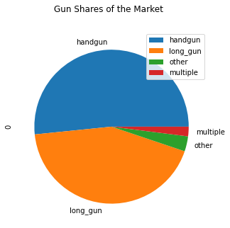

```python
plot = df.plot(kind='pie',title='Gun Shares of the Market', subplots=True,  figsize=(5, 5))
```